# Chapter 5: Classification

```r
# Libraries
library(tidyverse)
library(kableExtra)
library(modelr)
library(klaR)
library(ggtext)
library(MASS) # linear discriminant analysis
library(viridis)
library(broom)
library(mgcv)
library(ggtext)

# Set ggplot2 theme
my_theme <- theme(
  panel.grid = element_blank(),
  panel.background = element_rect(fill = "white", color = "black"),
  plot.title = element_markdown(),
  plot.subtitle = element_markdown(),
  plot.caption = element_markdown()
)

# Set kableExtra printing layout
kable_layout <- function(df, caption) {
  df %>%
    kbl(caption = caption) %>%
    kable_styling(bootstrap_options = "striped", full_width = FALSE) %>%
    kable_classic_2()
}
```

## Learning Objectives and Notes

### Meeting 7/26

Learning Objectives:

- Describe a general approach to binary classification (tree models can be used for predicting multiple classes).
- Use naive Bayes to a binary categorical response from categorical predictors.
- Use linear discriminant analysis (LDA) to predict a binary categorical variable from normally distributed continuous or categorical predictors.
- Use logistic regression to predict a binary categorical response from predictors.

Notes:

- Bayes theorem calculates the probability of A given B, if you know the probability of B given A, and the probability of A, and the probability of B.
- Bayes theorem: $prob(true | class) = \frac{prob(class|true)prob(true)}{prob(class)}$
- For naive Bayes, it’s important to note that it’s generally used with categorical predictors. If dealing with numeric predictors, you could bin observations, but that could introduce bias. In other cases, predictors may already be binned (e.g., ages).
- Naive Bayes is “naive” because the predictors are assumed to be independent, which is not the case most of the time in real-world scenarios.
- LDA essentially takes covariance matrices and finds coefficients for predictors which maximizes the ratio of the sums of squares between groups and the sums of squares within groups.
- Logistic regression uses a transformation to shrink continuous responses in linear regression to be between 0 and 1. Additionally, instead of describing the mean response with a one unit change in the predictor, we describe the log-odds with a one unit change in the predictor. We can use the logistic function to re-write the log-odds as a probability of assigning to a particular class.

## Introduction

- Classification is a form of supervised machine learning in which we use training data with defined binary outcomes to try and predict the outcome of new data (e.g., is an image a cat or a dog, or is an email normal or spam).
- In other cases, there are multiple “classes” in which a record could belong to, and tools can provide a probability of classification with thresholds used to determine the ultimate decision.
- In cases with multiple “classes,” the problem can be broken up into several binary decisions: for example, 0 or 1, and then if 1, is an observation 1 or 2.
- The basic workflow for these classification problems is as follows: establish a probability threshold, above which a record is assigned for a given class; estimate the probability that a record belongs to various classes; if the estimated probability is greater than the established threshold, assign the record to that class.

## Naive Bayes

```r
# Import data and convert all character fields to factors
loan_data <- read_csv("../data/loan_data.csv") %>%
  rename("record" = X1) %>%
  mutate(across(where(is.character), factor))

head(loan_data) %>%
  kable_layout(caption = "Subset of loan data")
```

Subset of loan data

| record | status | loan_amnt | term | annual_inc | dti | payment_inc_ratio | revol_bal | revol_util | purpose | home_ownership | delinq_2yrs_zero | pub_rec_zero | open_acc | grade | outcome | emp_length | purpose_ | home_ | emp_len_ | borrower_score |
| --- | --- | --- | --- | --- | --- | --- | --- | --- | --- | --- | --- | --- | --- | --- | --- | --- | --- | --- | --- | --- |
| 1 | Charged Off | 2500 | 60 months | 30000 | 1.00 | 2.39320 | 1687 | 9.4 | car | RENT | 1 | 1 | 3 | 4.8 | default | 1 | major_purchase | RENT | > 1 Year | 0.65 |
| 2 | Charged Off | 5600 | 60 months | 40000 | 5.55 | 4.57170 | 5210 | 32.6 | small_business | OWN | 1 | 1 | 11 | 1.4 | default | 5 | small_business | OWN | > 1 Year | 0.80 |
| 3 | Charged Off | 5375 | 60 months | 15000 | 18.08 | 9.71600 | 9279 | 36.5 | other | RENT | 1 | 1 | 2 | 6.0 | default | 1 | other | RENT | > 1 Year | 0.60 |
| 4 | Charged Off | 9000 | 36 months | 30000 | 10.08 | 12.21520 | 10452 | 91.7 | debt_consolidation | RENT | 1 | 1 | 4 | 4.2 | default | 1 | debt_consolidation | RENT | > 1 Year | 0.50 |
| 5 | Charged Off | 10000 | 36 months | 100000 | 7.06 | 3.90888 | 11997 | 55.5 | other | RENT | 1 | 1 | 14 | 5.4 | default | 4 | other | RENT | > 1 Year | 0.55 |
| 6 | Charged Off | 21000 | 36 months | 105000 | 13.22 | 8.01977 | 32135 | 90.3 | debt_consolidation | RENT | 1 | 1 | 7 | 5.8 | default | 11 | debt_consolidation | RENT | > 1 Year | 0.40 |

- We’ll use a naive Bayes model to classify the loan outcome based on the purpose of the loan, whether or not the borrower owns or rents a home, and length of employment of the borrower. First, we’ll look at the number of different outcomes in this data set.

Loan outcome data

| outcome | count |
| --- | --- |
| default | 22671 |
| paid off | 22671 |

- Now, we’ll fit the naive Bayes model to classify the loans as either `default` (failure to meet the legal obligations of the loan), or `paid off`.

```r
# Print model output
loan_naive_bayes$tables
```

```
$purpose_
          var
grouping   credit_card debt_consolidation home_improvement major_purchase    medical      other small_business
  default   0.15151515         0.57571347       0.05981209     0.03727229 0.01433549 0.11561025     0.04574126
  paid off  0.18759649         0.55215915       0.07150104     0.05359270 0.01424728 0.09990737     0.02099599

$home_
          var
grouping    MORTGAGE       OWN      RENT
  default  0.4313440 0.0832782 0.4853778
  paid off 0.4894800 0.0808963 0.4296237

$emp_len_
          var
grouping     < 1 Year   > 1 Year
  default  0.04728508 0.95271492
  paid off 0.03105289 0.96894711
```

- The model results are proportional to $P(X|Y)$, or the conditional probability of some feature, given the outcome. For example, if we look at the `purpose_` field, we can see the conditional probabilities of debt consolidation for the default class versus the paid-off class. Thus, if we wanted to use these results to predict the loan status of a new credit card loan for a borrower that owns a home and has been employed for more than one year, the equation would look like this (for one outcome): $P(Y|X) = P(default|creditcard) * P(default|own) * P(default|>1 year) * P(default)$, which ultimately works out to $P(Y|X) = 0.15151515 * 0.0832782 * 0.95271492 * 0.5 = 0.006010635$.
- We get the a priori probabilities from the `apriori` slot in the `loan_naive_bayes` object, which is simply the probability of a `default` or `paid off` outcome, given the number in each category and the total number of loans in the data set. We can compare the above probability of a default loan, compared to a paid off loan, by substituting the other conditional probabilities: $P(Y|X) = P(paidoff|creditcard) * P(paidoff|own) * P(paidoff|>1 year) * P(paidoff)$, which works out to $P(Y|X) = 0.18759649 * 0.0808963 * 0.96894711 * 0.5 = 0.007352304$.
- Based on these two results, we would conclude that a borrower that owns a home and has been employed for more than 1 year will pay off a credit card loan.

```r
predict(loan_naive_bayes, new_loan)
```

```
$class
[1] paid off
Levels: default paid off

$posterior
       default  paid off
[1,] 0.4497989 0.5502011
```

- We can take this one step further and classify the observations as `default` or `paid off` based solely on these predictors using the naive Bayes results.

Proportion of correct and incorrect loan outcome assignments using a naive Bayes classifier

| assignment | count | count_prop |
| --- | --- | --- |
| correct | 292 | 0.54 |
| incorrect | 244 | 0.46 |

- We can see from this table that the naive Bayes classifier only correctly assigned records about 54% of the time, indicating there are likely other features that are important to categorize outcomes.
- [This](https://uc-r.github.io/naive_bayes) is another good tutorial for implementing naive Bayes models using other packages like `caret` and `h2o` and employing a cross-validation framework to evaluate the model performance.
- One thing to note is that if a feature doesn’t appear in a training set for the model for a particular response class, the posterior probability of the response will be 0, since we’re multiplying conditional probabilities for each feature and response class. To mitigate this problem, we can use a Laplace smoother, which adds a small number to the counts in each feature, such that the counts of each feature are non-zero.
- We can apply this same naive Bayes algorithm to the `iris` data set, which is composed of 150 records and 5 variables including `Sepal.Length`, `Sepal.Width`, `Petal.Length`, `Petal.Width`, and `Species`.

Probability of correct iris species assignments using the naive Bayes classifier

| assignment | count | count_prob |
| --- | --- | --- |
| correct | 144 | 0.96 |
| incorrect | 6 | 0.04 |

## Discriminant Analysis

- One of the most widely used discriminant analyses is the linear discriminant analysis (LDA), which applies a discriminant function to maximize the separation of records into distinct classes using the discriminant weights.
- Covariance describes the joint relationship between two variables. For example, if greater values of one variable are associated with greater values of another variable, the covariance between them is positive; the same holds true with lesser values of one variable and lesser values of another. If greater values of one are associated with lesser values of another, the covariance is negative.
- For example, using the `iris` data set again, we can find the covariance between each of the variables after removing the `Species` field. Note, covariance is not constrained between -1 and 1, but depends on the scale of the variables being considered.

```r
iris %>%
  dplyr::select(-Species) %>%
  cov()
```

```
             Sepal.Length Sepal.Width Petal.Length Petal.Width
Sepal.Length    0.6856935  -0.0424340    1.2743154   0.5162707
Sepal.Width    -0.0424340   0.1899794   -0.3296564  -0.1216394
Petal.Length    1.2743154  -0.3296564    3.1162779   1.2956094
Petal.Width     0.5162707  -0.1216394    1.2956094   0.5810063
```

- Fisher’s LDA focuses on distinguishing the variation between groups ($SS_{between}$, or the squared distance between the two group means) and the variation within groups ($SS_{within}$, or the spread around the mean within each group), trying to maximize the former and minimize the latter.
- Specifically, LDA focuses on maximizing the sums of squares between groups to find a linear combination of features that maximizes the ability to distinguish between groups.
- We can use the `MASS::lda()` function with the `loan3000.csv` data to classify loan outcomes using the `borrower_score` and `payment_inc_ratio`. The output will be the estimated linear discriminator weights, or essentially the coefficient used to estimate the probability that a record belongs to one class or another.

Linear discriminator weights to predict loan outcome

| Feature | LD1 |
| --- | --- |
| borrower_score | 7.1758388 |
| payment_inc_ratio | -0.0996756 |

- We can then use the `predict()` function to use the linear discriminator weights to estimate the posterior probability that a loan will have the outcome `default` or `paid off`.

Subset of posterior probabilities of loan outcomes using LDA

| record | default | paid.off |
| --- | --- | --- |
| 1 | 0.5535437 | 0.4464563 |
| 2 | 0.5589534 | 0.4410466 |
| 3 | 0.2726962 | 0.7273038 |
| 4 | 0.5062538 | 0.4937462 |
| 5 | 0.6099525 | 0.3900475 |
| 6 | 0.4107406 | 0.5892594 |

- Now, we can plot the predicted values using the LDA results with `ggplot2` to see the separation of observations into different classes. The linear discriminants, or the scores on each of the linear discriminant axis for each observation, are given in the `x` slot in the `predict()` output.

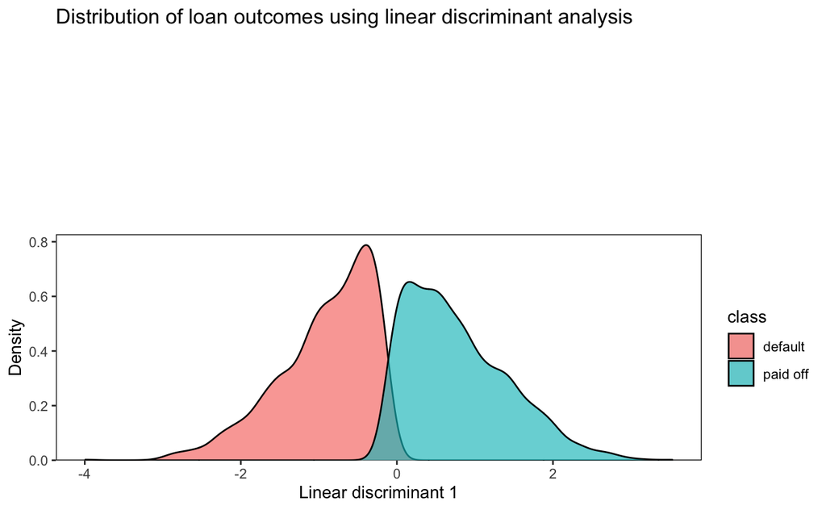

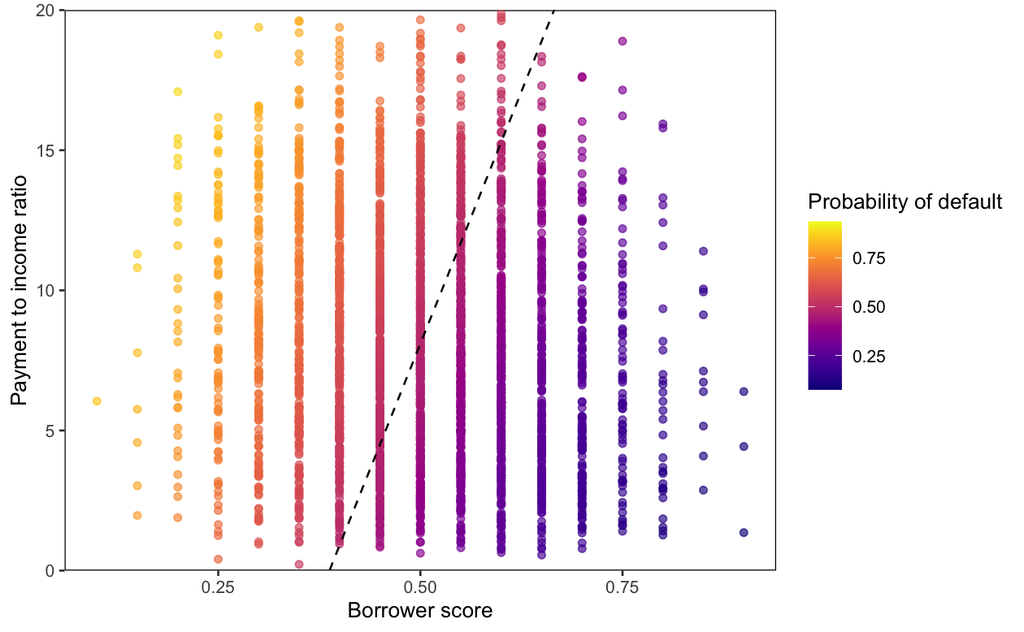

- From this plot, we can see the decision boundary is the dashed line, where the probability of default is 0.50. Warmer hues indicate a higher probability of assignment to default, while cooler hues indicate lower probability of default.
- There are other approaches to discriminant analysis, and one of the best known is quadratic discriminant analysis (QDA). The main difference between LDA and QDA is that the former assumes the covariance matrix is the same for both groups, while in the latter application, the covariance matrix can be different.

## Logistic Regression

### Logistic Response Function and the Logit

- Logistic regression is similar to simple and multiple linear regression, but instead of a continuous response, we’re looking at a binary response.
- Ultimately, we’re modeling the probability that an observation takes on “class” of binary response (e.g., “yes” or “no”), but we need the logistic response function or inverse logit function to transform the linear function such that the resulting probability is between 0 and 1. Put another way, it squeezes the output of a linear function to be between 0 and 1.
- The logistic function takes the form: $P(X) = \frac{e^{B_0+B_1X_1+...+B_nX_n}}{1 + e^{B_0 + B_1X_1 + ... + B_nX_n}}$
- This expression can be manipulated to get the odds, which is the probability of “success” divided by the probability of “failure:” $\frac{P(X)}{1-P(X)} = e^{B_0 + B_1X_1 + ... + B_nX_n}$
- The odds can take on any number from 0 to infinity, with higher values corresponding to higher probabilities of success relative to the probability of failure.
- We can take the logarithm of each side of the above expression to get the following: $log(\frac{P(X)}{1-P(X)}) = B_0 + B_1X_1 + ... + B_nX_n$, or the log-odds (also called the logit). This equates to a linear relationship with $X$.
- When interpreting the linear regression model, each unit change in $X$ equates to a $B_n$ increase in the mean response, $Y$. However, in logistic regression, each unit change in $X$ equates to a one unit increase in the log odds of $B_n$, which can be rewritten as $e^{B_n}$.
- We can take this one step further to use in classification by establishing a probability threshold, above which an observation will be grouped into a category (e.g., probability of 0.5).

### Logistic Regression and the GLM

- We can use the `glm()` function to fit a logistic regression model, since it is an extension of the GLM, but specifying `family = "binomial"` in the function call. We’ll use the loan data again to classify the outcome using the payment to income ratio, purpose of the loan, home ownership status, length of employment, and the borrower score.

Coefficients from logistic regression modeling loan outcomes

| term | coefficient |
| --- | --- |
| (Intercept) | -1.6380924 |
| payment_inc_ratio | -0.0797366 |
| purpose_debt_consolidation | -0.2493727 |
| purpose_home_improvement | -0.4077426 |
| purpose_major_purchase | -0.2296276 |
| purpose_medical | -0.5104792 |
| purpose_other | -0.6206627 |
| purpose_small_business | -1.2152610 |
| home_OWN | -0.0483297 |
| home_RENT | -0.1573197 |
| emp_len_> 1 Year | 0.3567310 |
| borrower_score | 4.6126378 |

| outcome_assignment | count |
| --- | --- |
| correct | 28859 |
| incorrect | 16483 |

- The logistic regression is popular in part because of its interpretability in terms of the odds. Once we exponentiate the log-odds result from the model coefficient, we can interpret the odds as a multiplicative difference between two responses. Because the untransformed model results are on the log-scale, a one unit increase equates to a $exp(1)$ increase in the odds ratio, or 2.72.

### Fitting the model

- One of the major differences between linear regression and logistic regression is how the latter model is fit. In linear regression, we use least squares to find the coefficients of the predictors and fit the model, then evaluate the model fit using the root mean squared error (RMSE). This metric is simply the sum of all of the squared distances between the predicted values and the actual values, all divided by the number of observations.
- Unlike linear regression, in logistic regression, maximum likelihood is used to fit the model. Maximum likelihood estimation (MLE) is essentially the process of identifying parameter values that are most likely to have produced the observed data.
- In the context of the logistic regression, MLE finds the solution with the log-odds that best fits the observed data.
- In MLE, the set of parameters $\theta$ are chosen that maximize the probability of the data given the predictor values. To estimate different logistic regression models or other models fitted using MLE, we can use the deviance metric, with lower deviance estimates corresponding to better model fit.

### Assessing the model

- Since the ultimate goal is to develop a model that can be used to classify new data, we can evaluate a logistic regression model by how accurate it is when making predictions.

```r
# Print summary of the logistic regression model
summary(loan_logistic_mod)
```

```
Call:
glm(formula = outcome ~ payment_inc_ratio + purpose_ + home_ +
    emp_len_ + borrower_score, family = "binomial", data = loan_data)

Deviance Residuals:
     Min        1Q    Median        3Q       Max
-2.15528  -1.07421   0.05853   1.06908   2.51951

Coefficients:
                            Estimate Std. Error z value Pr(>|z|)
(Intercept)                -1.638092   0.073708 -22.224  < 2e-16 ***
payment_inc_ratio          -0.079737   0.002487 -32.058  < 2e-16 ***
purpose_debt_consolidation -0.249373   0.027615  -9.030  < 2e-16 ***
purpose_home_improvement   -0.407743   0.046615  -8.747  < 2e-16 ***
purpose_major_purchase     -0.229628   0.053683  -4.277 1.89e-05 ***
purpose_medical            -0.510479   0.086780  -5.882 4.04e-09 ***
purpose_other              -0.620663   0.039436 -15.738  < 2e-16 ***
purpose_small_business     -1.215261   0.063320 -19.192  < 2e-16 ***
home_OWN                   -0.048330   0.038036  -1.271    0.204
home_RENT                  -0.157320   0.021203  -7.420 1.17e-13 ***
emp_len_> 1 Year            0.356731   0.052622   6.779 1.21e-11 ***
borrower_score              4.612638   0.083558  55.203  < 2e-16 ***
---
Signif. codes:  0 ‘***’ 0.001 ‘**’ 0.01 ‘*’ 0.05 ‘.’ 0.1 ‘ ’ 1

(Dispersion parameter for binomial family taken to be 1)

    Null deviance: 62857  on 45341  degrees of freedom
Residual deviance: 57515  on 45330  degrees of freedom
AIC: 57539

Number of Fisher Scoring iterations: 4
```

```r
summary(loan_logistic_gam)
```

```
Family: binomial
Link function: logit

Formula:
outcome ~ s(payment_inc_ratio) + purpose_ + home_ + emp_len_ +
    s(borrower_score)

Parametric coefficients:
                           Estimate Std. Error z value Pr(>|z|)
(Intercept)                 0.02833    0.05702   0.497    0.619
purpose_debt_consolidation -0.24836    0.02763  -8.988  < 2e-16 ***
purpose_home_improvement   -0.40994    0.04678  -8.763  < 2e-16 ***
purpose_major_purchase     -0.23762    0.05395  -4.405 1.06e-05 ***
purpose_medical            -0.51696    0.08705  -5.939 2.87e-09 ***
purpose_other              -0.62777    0.03981 -15.768  < 2e-16 ***
purpose_small_business     -1.22389    0.06344 -19.294  < 2e-16 ***
home_OWN                   -0.04964    0.03805  -1.305    0.192
home_RENT                  -0.15788    0.02122  -7.441 1.00e-13 ***
emp_len_> 1 Year            0.35323    0.05264   6.711 1.94e-11 ***
---
Signif. codes:  0 ‘***’ 0.001 ‘**’ 0.01 ‘*’ 0.05 ‘.’ 0.1 ‘ ’ 1

Approximate significance of smooth terms:
                       edf Ref.df Chi.sq p-value
s(payment_inc_ratio) 7.664  8.578   1084  <2e-16 ***
s(borrower_score)    4.168  5.054   3011  <2e-16 ***
---
Signif. codes:  0 ‘***’ 0.001 ‘**’ 0.01 ‘*’ 0.05 ‘.’ 0.1 ‘ ’ 1

R-sq.(adj) =  0.113   Deviance explained = 8.59%
UBRE = 0.26815  Scale est. = 1         n = 45342
```

### Analysis of residuals

- We can calculate the partial residuals, or the residuals associated with each feature for the logistic regression model, just as we have done previously for the linear regression models.

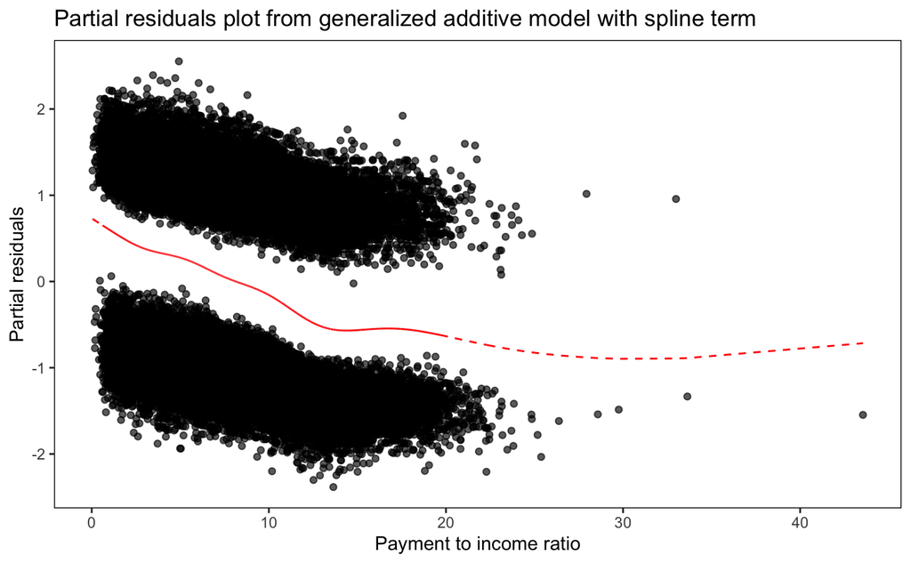

- Here, the points above the red line correspond to paid off loans, while the cloud of points below the red line correspond to defaulted loans.

## Evaluating Classification Models

- Often, training sets are constructed from the data, to train and fit a statistical model, which can then be applied to a new, unseen test set. The accuracy of the model can then be evaluated based on how well it predicts the true outcomes in the test set.
- Accuracy is a common metric used, defined as the sum of the true positives and true negatives, divided by the sample size.

### Confusion Matrix

- A confusion matrix is a table showing the number of correct and incorrect predictions made by the classification model by the type of response.

```r
# Put these into a data frame and assign classes
df <- data.frame(predictions_y = predictions_y,
           true_y = true_y) %>%
  mutate(class = case_when(
    true_y == 1 & predictions_y == 1 ~ "true_positive",
    true_y == 0 & predictions_y == 0 ~ "true_negative",
    true_y == 0 & predictions_y == 1 ~ "false_positive",
    TRUE ~ "false_negative")
  )
```

[output not shown]

| outcome | count |
| --- | --- |
| default | 8378 |

- In cases where there the outcomes are unbalanced, such as when a particular class is rare, we may not need to worry about identifying each of those rare cases. Although it won’t be as accurate (i.e., it may not be 100% accurate), it will generally correctly classify observations on new data.

### Precision, recall, and specificity

Confusion matrix and diagnostic metrics from logistic regression model

| false_negative | false_positive | true_negative | true_positive | precision | sensitivity | specificity |
| --- | --- | --- | --- | --- | --- | --- |
| 8051 | 8378 | 14293 | 14620 | 0.64 | 0.64 | 0.63 |

### ROC curve

- There is a trade-off between model sensitivity and specificity: the former measures how well the model classifies positive outcomes, while the latter captures how well the model classifies negative outcomes, ideally not classifying observations incorrectly.
- The receiver operating characteristics curve, or ROC curve, captures both of these metrics and plots the specificity on the x-axis and the sensitivity on the y-axis.

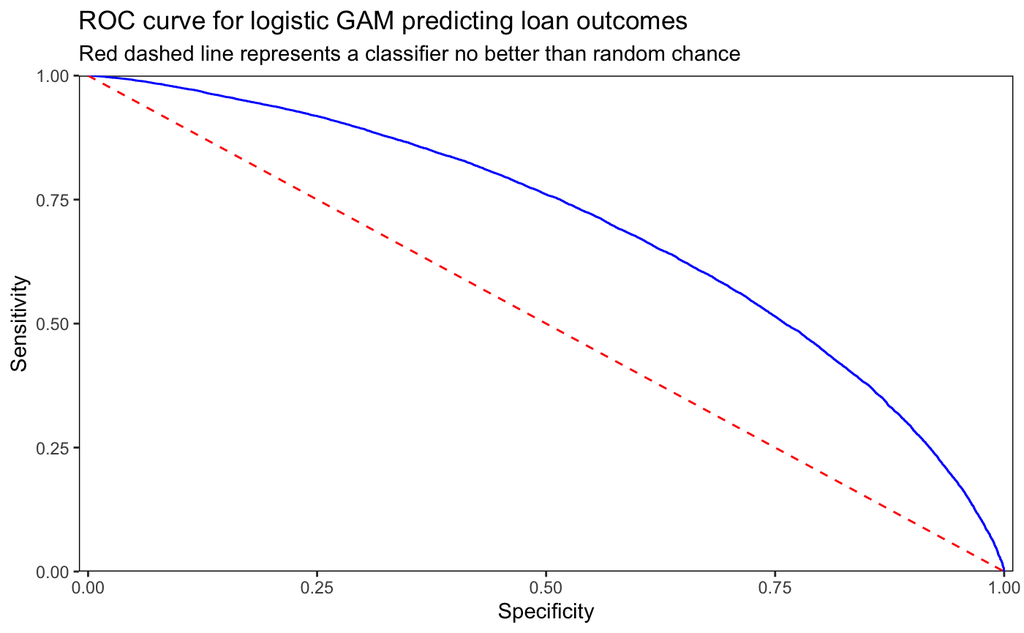

- In the ROC curve above, the red dashed line represents a classifier that does no better than random chance at predicting the outcomes. The blue line tracks the relationship between specificity and sensitivity. The former measures the number of true negatives divided by the sum of true negatives and false positives, effectively acting as a measure of the classifier’s ability to correctly identify 0’s. A classifier which perfectly predicts all negatives (0’s) without detecting any false positives would have a specificity value of 1.00.
- In contrast, sensitivity measures the number of true positives divided by the sum of the true positives plus the false negatives, effectively acting as a measure of the classifier’s ability to correctly identify positives (1’s) without detecting false negatives (i.e., outcomes that are actually 1’s but classified as 0’s). In other words, a model which perfectly predicts all 1’s without any mistakes will have a sensitivity value of 1.00.

### AUC

- The area underneath the curve (AUC) is a metric of the total area underneath the ROC curve, and is useful as a single summary statistic for comparing classifiers. Ideally, we strive for AUC of 1.00, which correctly classifies all 1’s and 0’s, without errors; a completely ineffective classifier, or one that does no better than random chance, will have an AUC value of 0.5.
- We can calculate the AUC for the loan data using the code snippit below.

```r
# Calculate AUC for the logistic GAM model fitted to loan data
roc_df %>%
  arrange(sensitivity) %>%
  summarise(AUC = sum(sensitivity * diff(1 - specificity)))
```

```
longer object length is not a multiple of shorter object length
```

| AUC |
| --- |
| 0.692623 |

### Lift and Uplift

- One of the issues with classification models is the rare case problem. In this situation, you would typically want to lower the probability threshold to call 1’s that were important (in the case of insurance fraud, for example). However, you are making a compromise because some 0’s will inevitably be called as 1’s (false positives).
- Lift is the gain (lift is also called gain) in predictive ability of the model compared to random chance in different percentiles of the predictor values. We first need to order observations by probability of being 1’s, and then look at different percentiles to see how much better the model does at random chance.

Loan data records ordered by the probability of success

| record | log_odds | sensitivity | specificity | prob_success |
| --- | --- | --- | --- | --- |
| 40830 | 2.956265 | 0.0000441 | 1 | 0.9505588 |
| 36762 | 2.913499 | 0.0000882 | 1 | 0.9485097 |
| 34002 | 2.891473 | 0.0001323 | 1 | 0.9474233 |
| 40537 | 2.882588 | 0.0001764 | 1 | 0.9469790 |
| 35923 | 2.832812 | 0.0002205 | 1 | 0.9444234 |
| 30916 | 2.822037 | 0.0002647 | 1 | 0.9438551 |

- Ultimately, a lift chart may help the user decide an appropriate probability threshold cutoff.

### Uplift

- Uplift refers to the improvement in response predicted for an individual case with two different treatments (e.g., in the case of A/B experiments). This can be done by looking at the differences in scoring individual observations based on the different treatments.

## Strategies for Imbalanced Data